# 采购招聘市场分析

## 总述

本次有效数据3756条（城市发布量>=40），分析采购岗位的市场招聘和薪酬水平，将从如下方面分析：

## 01.城市分布

[figure not shown]

roadmap

## 02.行业分布

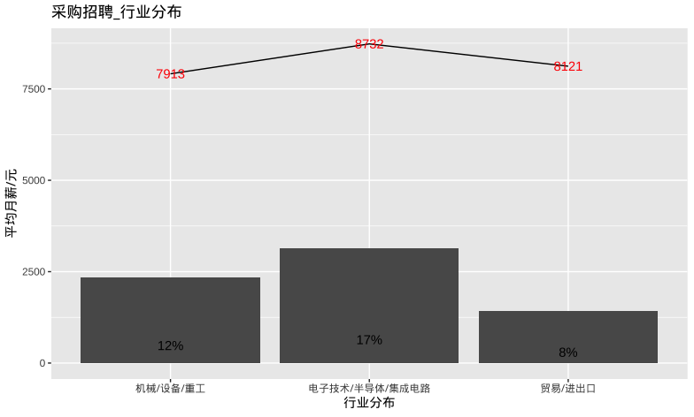

industry

## 03.企业规模

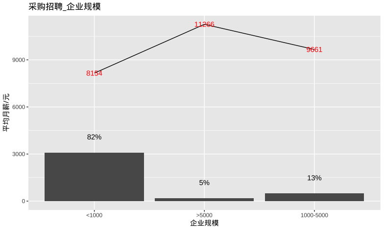

com_size

## 04.工作经验

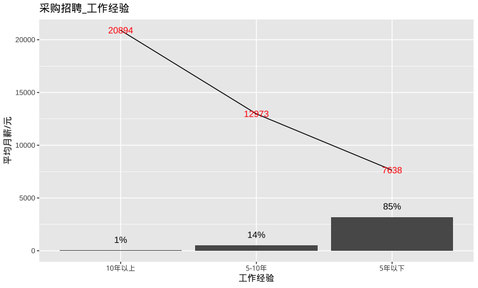

experience

## 05.学历要求

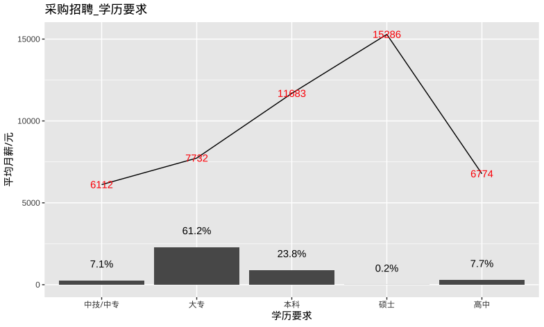

education

## 06.工作简述

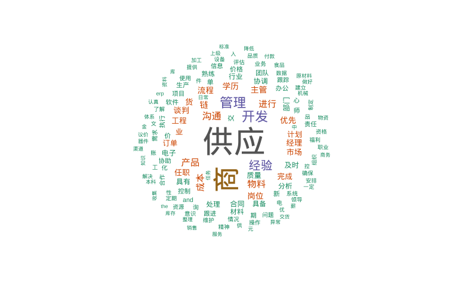

job_briefing